# Activity 1: Statistical Maps I

# Activity 1: Statistical Maps I

Remember, you can download the source file for this activity from [here](https://github.com/paezha/Spatial-Statistics-Course).

## Housekeeping Questions

Answer the following questions:

1. What are the office hours of your instructor this term?
2. How are assignments graded?
3. What is the policy for late assignments in this course?

## Learning Objectives

In this activity you will:

1. Discuss statistical maps and what makes them interesting.

## Preliminaries

In the practice that preceded this activity, you used `ggmap` to create a proportional symbol map, a mapping technique used in spatial statistics for visualization of geocoded event information. As well, you implemented a simple technique called kernel analysis to the map to explore the distribution of events in the case of the cholera outbreak of Soho in London in 1854. Geocoded events are often called *point patterns*, so with the cholera data you were working with a point pattern.

In this activity, we will map another type of spatial data, called *areal data*. Areas are often administrative or political jurisdictions.

For this activity you will need the following:

- An R markdown notebook version of this document (the source file).
- A package called `geog4ga3`.

Note that `ls()` lists all objects currently on the worspace.

Load the libraries you will use in this activity:

```r
library(tidyverse)
library(sf)
library(geog4ga3)
```

## Creating a simple thematic map

If you successfully loaded package `geog4ga3` a dataset called `HamiltonDAs` should be available for analysis:

```r
data(HamiltonDAs)
```

Check the class of this object:

```r
class(HamiltonDAs)
```

```
[1] "sf"         "data.frame"
```

As you can see, this is an object of class `sf`, which stands for *simple features*. Objects of this class are used in the R package `sf` (see [here](https://cran.r-project.org/web/packages/sf/vignettes/sf1.html)) to implement standards for [spatial objects](https://en.wikipedia.org/wiki/Simple_Features).

You can examine the contents of the dataset by means of `head` (which will show the top rows):

```r
head(HamiltonDAs)
```

```
Simple feature collection with 6 features and 7 fields
geometry type:  MULTIPOLYGON
dimension:      XY
bbox:           xmin: 563306.2 ymin: 4777681 xmax: 610844.5 ymax: 4793682
epsg (SRID):    26917
proj4string:    +proj=utm +zone=17 +ellps=GRS80 +towgs84=0,0,0,0,0,0,0 +units=m +no_defs
    ID GTA06       VAR1      VAR2      VAR3      VAR4      VAR5
1 2671  5030 0.74650172 0.2596975 0.6361925 0.2290084 0.7223464
2 2716  5077 0.78107142 0.4413119 0.5690740 0.8997258 0.4163702
3 2710  5071 0.78824936 0.4632757 0.4197216 0.1619401 0.3052948
4 2745  5108 0.82064933 0.6365193 0.9504535 0.4992477 0.6046399
5 2810  5177 0.09131849 0.4455965 0.3539603 0.4919869 0.6366968
6 2740  5103 0.22257665 0.6288826 0.1341962 0.6635202 0.4429712
                        geometry
1 MULTIPOLYGON (((605123.4 47...
2 MULTIPOLYGON (((606814 4784...
3 MULTIPOLYGON (((605293 4785...
4 MULTIPOLYGON (((607542.7 47...
5 MULTIPOLYGON (((564681.8 47...
6 MULTIPOLYGON (((574373.4 47...
```

Or obtain the summary statistics by means of `summary`:

```r
summary(HamiltonDAs)
```

```
       ID          GTA06          VAR1             VAR2
 2299   :  1   4050   :  1   Min.   :0.0000   Min.   :0.0000
 2300   :  1   4051   :  1   1st Qu.:0.3680   1st Qu.:0.3800
 2301   :  1   4052   :  1   Median :0.5345   Median :0.4937
 2302   :  1   4053   :  1   Mean   :0.5241   Mean   :0.4966
 2303   :  1   4054   :  1   3rd Qu.:0.6938   3rd Qu.:0.6091
 2304   :  1   4055   :  1   Max.   :1.0000   Max.   :1.0000
 (Other):291   (Other):291
      VAR3             VAR4             VAR5
 Min.   :0.0000   Min.   :0.0000   Min.   :0.0000
 1st Qu.:0.3521   1st Qu.:0.2989   1st Qu.:0.2998
 Median :0.5699   Median :0.5476   Median :0.4810
 Mean   :0.5548   Mean   :0.5325   Mean   :0.5001
 3rd Qu.:0.7378   3rd Qu.:0.7894   3rd Qu.:0.6915
 Max.   :1.0000   Max.   :1.0000   Max.   :1.0000

          geometry
 MULTIPOLYGON :297
 epsg:26917   :  0
 +proj=utm ...:  0
```

The above will include a column for the geometry of the spatial features.

The dataframe includes all *Dissemination Areas* (or DAs for short) for the Hamilton Census Metropolitan Arean in Canada. DAs are a type of geography used by the Census of Canada, in fact the smallest geography that is publicly available.

To create a siple map we can use `ggplot2`, which previously we used to map points. Now, the geom for objects of class `sf` can be used to plot areas. To create such a map, we layer a geom object of type `sf` on a `ggplot2` object. For instance, to plot the DAs:

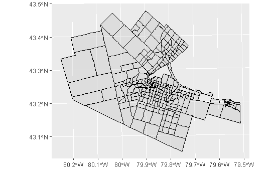

```r
#head(HamiltonDAs)
ggplot(HamiltonDAs) +
  geom_sf(fill = "gray", color = "black", alpha = .3, size = .3)
```

We selected color “black” for the polygons, with a transparency alpha = 0.3 (alpha = 0 is completely transparent, alpha = 1 is completely opaque, try it!), and line size 0.3.

This map only shows the DAs, which is nice. However, as you saw in the summary of the dataframe above, in addition to the geometric information, a set of (generic) variables is also included, called VAR1, VAR2,…, VAR5.

Thematic maps can be created using these variables. The next chunk of code plots the DAs and adds info. The `fill` argument is used to select a variable to color the polygons. The function `cut_number` is used to classify the values of the variable in $k$ groups of equal size, in this case 5 (notice that the lines of the polygons are still black). The `scale_fill_brewer` function can be used to select different *palettes* or coloring schemes):

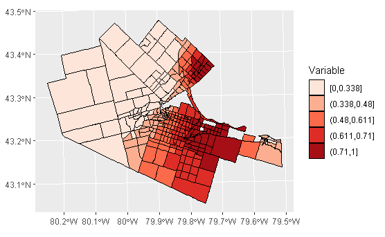

```r
ggplot(HamiltonDAs) +
  geom_sf(aes(fill = cut_number(HamiltonDAs$VAR1, 5)), color = "black", alpha = 1, size = .3) +
  scale_fill_brewer(palette = "Reds") +
  coord_sf() +
  labs(fill = "Variable")
```

Now you have seen how to create a thematic map with polygons (areal data), you are ready for the following activity.

## Activity

1. Create thematic maps for variables VAR1 through VAR5 in the dataframe `HamiltonDAs`. Remember that you can introduce new chunks of code.

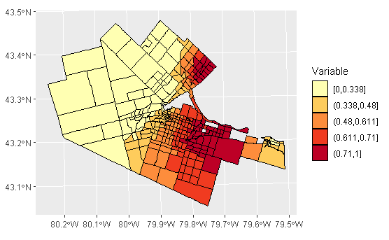

```r
ggplot(HamiltonDAs) +
  geom_sf(aes(fill = cut_number(HamiltonDAs$VAR1, 5)), color = "black", alpha = 1, size = .3) +
  scale_fill_brewer(palette = "YlOrRd") +
  coord_sf() +
  labs(fill = "Variable")
```

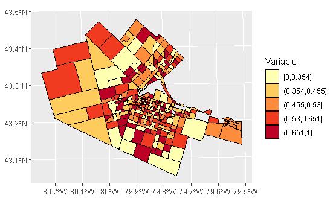

```r
ggplot(HamiltonDAs) +
  geom_sf(aes(fill = cut_number(HamiltonDAs$VAR2, 5)), color = "black", alpha = 1, size = .3) +
  scale_fill_brewer(palette = "YlOrRd") +
  coord_sf() +
  labs(fill = "Variable")
```

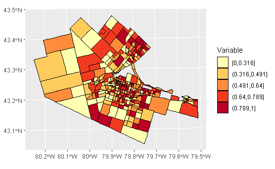

```r
ggplot(HamiltonDAs) +
  geom_sf(aes(fill = cut_number(HamiltonDAs$VAR3, 5)), color = "black", alpha = 1, size = .3) +
  scale_fill_brewer(palette = "YlOrRd") +
  coord_sf() +
  labs(fill = "Variable")
```

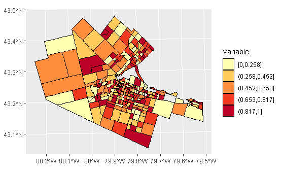

```r
ggplot(HamiltonDAs) +
  geom_sf(aes(fill = cut_number(HamiltonDAs$VAR4, 5)), color = "black", alpha = 1, size = .3) +
  scale_fill_brewer(palette = "YlOrRd") +
  coord_sf() +
  labs(fill = "Variable")
```

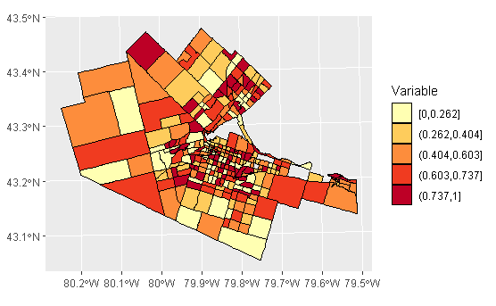

```r
ggplot(HamiltonDAs) +
  geom_sf(aes(fill = cut_number(HamiltonDAs$VAR5, 5)), color = "black", alpha = 1, size = .3) +
  scale_fill_brewer(palette = "YlOrRd") +
  coord_sf() +
  labs(fill = "Variable")
```

2. Imagine that these maps were found, and for some reason the variables were not labeled. They may represent income, or population density, or something else. Which of the five maps you just created is more interesting? Rank the five maps from most to least interesting. Explain the reasons for your ranking.